# 제21대 국회의원 선거

성남시 - 분당구와 행정동

xwMOOC

2019-03-14

# 1 분당구와 행정동

성남시 분당구를 대상으로 분당구에 속한 모든 동정보를 취합한다.

## 1.1 분당구 - 주민센터

먼저 [분당구 주민자치센터](http://www.bundang-gu.go.kr/dong/center/center/sub01.asp) 웹페이지에서 각동별 주민자치센터가 위치한 주소정보를 파악하고 웹크롤링하여 데이터프레임으로 생성시킨다.

```r
library(tidyverse)
library(sf)
library(httr)
library(rvest)

## 성남시 분당구 주민자치센터: 주소
Sys.setlocale("LC_ALL", "C")
```

```
[1] "C"
```

```r
dong_url <- 'http://www.bundang-gu.go.kr/dong/center/center/sub01.asp'

dong_dat <- dong_url %>%
  read_html() %>%
  html_node(xpath='//*[@id="container"]/div[2]/div[2]/div[2]/div[2]/table') %>%
  html_table(fill=TRUE)

Sys.setlocale("LC_ALL", "Korean")
```

```
[1] "LC_COLLATE=Korean_Korea.949;LC_CTYPE=Korean_Korea.949;LC_MONETARY=Korean_Korea.949;LC_NUMERIC=C;LC_TIME=Korean_Korea.949"
```

```r
dong_df <- dong_dat %>%
  select(-`홈페이지`) %>%
  filter(str_detect(`주소`, '[0-9]'))

DT::datatable(dong_df)
```

|  | 주민센터명 | 주소 | 주민자치센터전화번호 | 주민센터전화번호 |
| --- | --- | --- | --- | --- |
| 1 | 분당동 | 성남시 분당구 불정로 312(분당동) | 729-7617 | 729-7610 |
| 2 | 수내1동 | 성남시 분당구 내정로173번길 21(수내동) | 729-7635 | 729-7628 |
| 3 | 수내2동 | 성남시 분당구 내정로166번길 17(수내동) | 729-7657 | 729-7650 |
| 4 | 수내3동 | 성남시 분당구 돌마로356번길 43(수내동) | 729-7677 | 729-7670 |
| 5 | 정자동 | 성남시 분당구 황새울로18번길 14(정자동) | 729-7697 | 729-7690 |
| 6 | 정자1동 | 성남시 분당구 정자일로 145(정자동) | 729-8277 | 729-8260 |
| 7 | 정자2동 | 성남시 분당구 내정로 66(정자동) | 729-7717 | 729-7710 |
| 8 | 정자3동 | 성남시 분당구 돌마로 242(정자동) | 729-7737 | 729-7730 |
| 9 | 서현1동 | 성남시 분당구 중앙공원로39번길 35(서현동) | 729-7757 | 729-7750 |
| 10 | 서현2동 | 성남시 분당구 돌마로476번길 17(서현동) | 729-7775 | 729-7770 |

[output cut: 12 more lines]

## 1.2 분당구 - 주민센터 (위경도)

카카오 지도 API를 통해 주소를 던져 위도와 경도 정보를 받아내서 공간정보를 품은 데이터프레임을 생성시킨다. `get_lonlat()` 함수로 위경도정보를 받아오는 것을 시범운영한다.

```r
library(jsonlite)

get_lonlat <- possibly(function(addr) {
  # HTTP 요청을 실행합니다.
  addr_res <- GET(url = 'https://dapi.kakao.com/v2/local/search/address.json',
             query = list(query = addr),
             add_headers(Authorization = paste0("KakaoAK ", DAUM_MAP_API_KEY)))

  # KPMG 지리정보 데이터프레임
  addr_list <- addr_res %>%
    content(as = 'text') %>%
    fromJSON()

  ## 도로명주소
  res_df <- addr_list$documents$road_address %>%
    select(address_name, building_name, x,y)

  return(res_df)
}, otherwise = NA)

get_lonlat(dong_df$`주소`[1])
```

```
                   address_name       building_name                  x
1 경기 성남시 분당구 불정로 312 분당동 행정복지센터 127.13107934735257
                  y
1 37.37010786090126
```

전체 주민자치센터에 대한 주소를 카카오 지도 API에 던져 위경도를 받아낸다. 그리고 나서 후처리 작업(문자형 위경도 정보를 숫자형 위경도로 변환)을 수행한다.

```r
bundang_lonlat_dat <- dong_df %>%
  mutate(lonlat = map(`주소`, get_lonlat))

bundang_df <- bundang_lonlat_dat %>%
  mutate(lon = map(lonlat, 3) %>% unlist %>% as.numeric,
         lat = map(lonlat, 4) %>% unlist %>% as.numeric) %>%
  select(-contains("전화"), -lonlat)

bundang_df %>%
  DT::datatable() %>%
  DT::formatRound(c("lon", "lat"), digits=3)
```

|  | 주민센터명 | 주소 | lon | lat |
| --- | --- | --- | --- | --- |
| 1 | 분당동 | 성남시 분당구 불정로 312(분당동) | 127.131079347353 | 37.3701078609013 |
| 2 | 수내1동 | 성남시 분당구 내정로173번길 21(수내동) | 127.118064254975 | 37.3754628453461 |
| 3 | 수내2동 | 성남시 분당구 내정로166번길 17(수내동) | 127.12085490086 | 37.3724614159132 |
| 4 | 수내3동 | 성남시 분당구 돌마로356번길 43(수내동) | 127.126138175832 | 37.3668623332344 |
| 5 | 정자동 | 성남시 분당구 황새울로18번길 14(정자동) | 127.1115403336 | 37.3614492169641 |
| 6 | 정자1동 | 성남시 분당구 정자일로 145(정자동) | 127.105591434223 | 37.3630224636182 |
| 7 | 정자2동 | 성남시 분당구 내정로 66(정자동) | 127.115267870175 | 37.3660048371663 |
| 8 | 정자3동 | 성남시 분당구 돌마로 242(정자동) | 127.119553860207 | 37.3607890455323 |
| 9 | 서현1동 | 성남시 분당구 중앙공원로39번길 35(서현동) | 127.126047539187 | 37.3828610238967 |
| 10 | 서현2동 | 성남시 분당구 돌마로476번길 17(서현동) | 127.13460324181 | 37.376054271223 |

[output cut: 12 more lines]

# 2 분당구 시각화

취합된 성남시 분당구를 대상으로 분당구에 속한 모든 동정보를 지리정보로 시각화한다.

## 2.1 주민자치센터 위치

지방자치단체 위경도 정보를 `leaflet` 팩키지에 넣어 `addMarkers()` 함수로 지도상에 인터랙티브하게 팝업 마커로 시각화한다.

```r
library(leaflet)

leaflet() %>%
  addTiles() %>%
  addProviderTiles(providers$OpenStreetMap) %>%
  addMarkers(data=bundang_df, lng=~lon, lat=~lat, clusterOptions = markerClusterOptions(),
                   popup = ~ as.character(paste0("<strong>", paste0("주민센터명: ", `주민센터명`), "</strong><br>",
                                                 "-----------------------------------------------------------<br>",
                                                 "&middot; 주소: ", `주소`, "<br>")))
```

[interactive chart not shown]

## 2.2 분당구 - 주민센터 지도

```r
library(sf)

emd_sf <- st_read("data/shapefile/EMD_201902/TL_SCCO_EMD.shp")
```

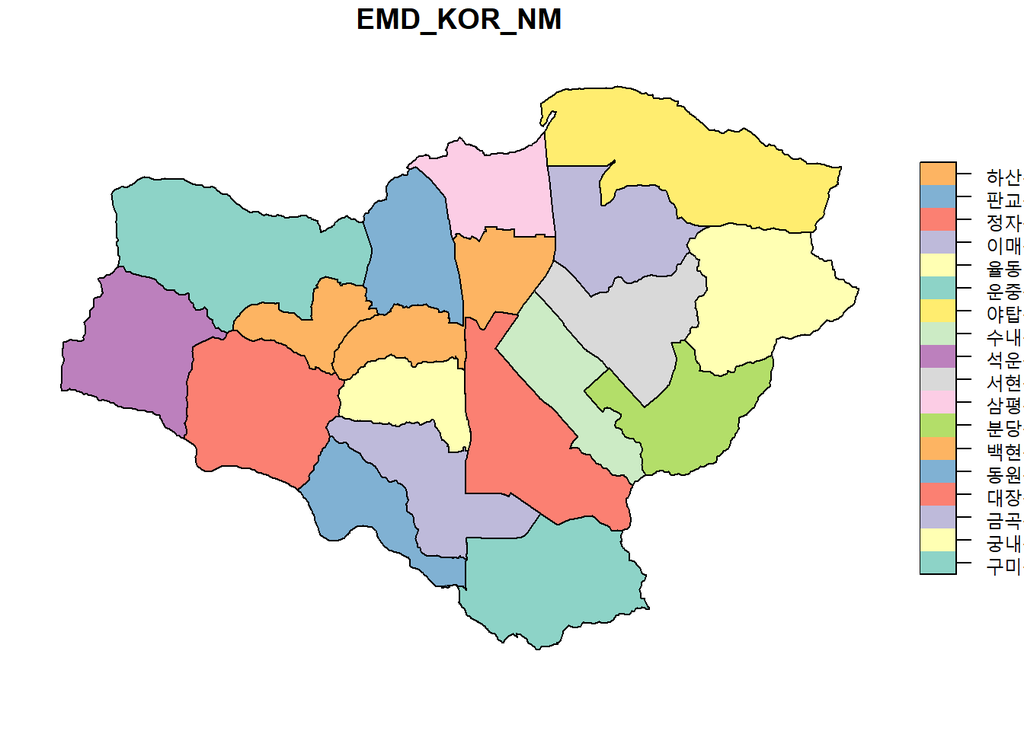

```r
bundang_sf <- emd_sf %>%
  filter(str_detect(EMD_CD, "^41135"))

## 인코딩 변경
bundang_sf$EMD_KOR_NM <- iconv(bundang_sf$EMD_KOR_NM, from = "CP949", to = "UTF-8", sub = NA, mark = TRUE, toRaw = FALSE)

## 좌표계 변경: 웹 메르카도(web mercator)
bundang_sf <- st_transform(bundang_sf, "+proj=longlat +datum=WGS84")

bundang_sf %>%
  select(EMD_KOR_NM) %>%
  plot()
```

`leaflet` 팩키지 `addPolygons`을 통해 지도위에 주제도를 입힐 수 있도록 인터랙티브 시각화를 준비한다.

```r
## 라벨
addr_labels <- sprintf(
  "<strong>%s</strong><br/>",
  bundang_sf$EMD_KOR_NM) %>% lapply(htmltools::HTML)

bundang_sf %>%
  leaflet() %>%
  addTiles() %>%
  addPolygons(opacity = 1.0, fillOpacity = 0.5,
              weight = 1,
              highlightOptions = highlightOptions(color = "black", weight = 3,  bringToFront = TRUE),
              label = addr_labels,
              labelOptions = labelOptions(
              style = list("font-weight" = "normal", padding = "3px 8px"),
              textsize = "15px",
              direction = "auto"))
```

[interactive chart not shown]

# 3 인터랙티브 지도

마커와 다각형(polygon)을 결합시켜 분당구 면적과 함께 주민자치센터 위치가 지도위에 나타나도록 인터랙티브하게 작업하여 마무리한다.

```r
leaflet(bundang_sf) %>%
  addTiles() %>%
  addPolygons(opacity = 1.0, fillOpacity = 0.5,
              weight = 1,
              highlightOptions = highlightOptions(color = "black", weight = 3,  bringToFront = TRUE),
              label = addr_labels,
              labelOptions = labelOptions(
              style = list("font-weight" = "normal", padding = "3px 8px"),
              textsize = "15px",
              direction = "auto")) %>%
    addProviderTiles(providers$OpenStreetMap) %>%
    addMarkers(data=bundang_df, lng=~lon, lat=~lat, clusterOptions = markerClusterOptions(),
                   popup = ~ as.character(paste0("<strong>", paste0("주민센터명: ", `주민센터명`), "</strong><br>",
                                                 "-----------------------------------------------------------<br>",
                                                 "&middot; 주소: ", `주소`, "<br>")))
```

[interactive chart not shown]